# Exam 1 Review Problems

STAT 251 Section 01

2026-09-16

These problems cover everything on Exam 1: Weeks 1 through 3, up to and including cumulative distributions. They are **more computational than the exam** by design. The exam asks you to interpret values, identify equations and read plots; these ask you to work the arithmetic behind them.

Work them by hand. Every dataset is small enough to do on paper, and a calculator is fine.

## Problem 1 — The anatomy of data

A researcher recorded the following information for each of six trees in a city park.

| Tree ID | Species | Health rating | Branches removed | Trunk width (cm) |
| --- | --- | --- | --- | --- |
| T-01 | Maple | Good | 3 | 31.4 |
| T-02 | Oak | Fair | 0 | 58.2 |
| T-03 | Maple | Excellent | 5 | 22.7 |
| T-04 | Pine | Good | 1 | 44.0 |
| T-05 | Oak | Poor | 8 | 61.9 |
| T-06 | Maple | Good | 2 | 27.5 |

**(a)** How many observations are in this data table, and how many variables? Which way round does a data table store them — one observation per row or one variable per row?

$\_\_\_\_\_\_\_\_$

**(b)** What is the value of $n$ for this sample?

$\_\_\_\_\_\_\_\_$

**(c)** Classify each of the four measured variables as nominal, ordinal, discrete or continuous.

| Variable | Your answer |
| --- | --- |
| Species |  |
| Health rating |  |
| Branches removed |  |
| Trunk width (cm) |  |

**(d)** These six trees are a sample. Describe the population the researcher is presumably interested in, and say whether $N$ is known.

## Problem 2 — Statistics, parameters, and inference

A city has 8,500 registered bicycles. A researcher takes a random sample of 200 of them and finds that 46 have no working lights. She also measures the age of each sampled bicycle and finds a mean age of 6.2 years.

**(a)** Give the values of $N$ and $n$.

$\_\_\_\_\_\_\_\_$

**(b)** Show how to compute the sample proportion of bicycles with no working lights. Which symbol denotes it?

$\_\_\_\_\_\_\_\_$

**(c)** For each quantity, say whether it is a **statistic** or a **parameter**, and give the symbol that denotes it.

| Quantity | Statistic or parameter | Symbol |
| --- | --- | --- |
| The mean age of the 200 sampled bicycles |  |  |
| The mean age of all 8,500 registered bicycles |  |  |
| The proportion of the 200 sampled with no lights |  |  |
| The proportion of all 8,500 with no lights |  |  |
| The standard deviation of the ages of the 200 sampled |  |  |
| The standard deviation of the ages of all 8,500 |  |  |

**(d)** The researcher reports the mean age of the 200 bicycles she measured, then uses it to estimate the mean age of all 8,500. Which of those two acts is descriptive statistics and which is inferential? Explain what makes the difference.

## Problem 3 — Reading the formulas

On the exam the formulas are provided **unlabeled** — the equations only, with no names. This problem is practice at telling them apart.

**(a)** Each equation below computes one of the quantities in the list. Write the name of the quantity next to its equation, and give the symbol it is denoted by.

> sample mean, from raw observations · sample mean, from a frequency table · sample mean, from a relative frequency table · population mean · sample proportion · population proportion · sample variance · sample standard deviation · range · interquartile range

| Equation | What it computes | Symbol |
| --- | --- | --- |
| $\dfrac{1}{n}\sum_{i=1}^{n} x_i$ |  |  |
| $\sqrt{\dfrac{1}{n-1}\sum_{i=1}^{n}(x_i - \bar{x})^{2}}$ |  |  |
| $Q3 - Q1$ |  |  |
| $\sum_{x} x\,RF(x)$ |  |  |
| $\dfrac{1}{N}\sum_{i=1}^{N} x_i$ |  |  |
| $\dfrac{\text{number of observations in the category}}{n}$ |  |  |
| $\max x - \min x$ |  |  |
| $\dfrac{\text{number of observations in the category}}{N}$ |  |  |
| $\dfrac{1}{n}\sum_{x} x\,F(x)$ |  |  |
| $\dfrac{1}{n-1}\sum_{i=1}^{n}(x_i - \bar{x})^{2}$ |  |  |

**(b)** *(notation)* Answer each in a few words.

| Question | Your answer |
| --- | --- |
| What does $n$ stand for? |  |
| What does $N$ stand for? |  |
| What does the *hat* on $\hat{p}$ tell you? |  |
| What does $\sum_{i=1}^{n} x_i$ mean? |  |

**(c)** Consider the following sample of five observations of a quantitative variable $X$:

$$X = \{ 2, \ 5, \ 6, \ 9, \ 13
\}$$

**Show how to compute** the mean $\bar{x}$ and the standard deviation $s$.

**(d)** Now consider the following sample of ten observations of a qualitative variable $Y$, the way each of ten students travelled to campus:

$$\begin{gathered}
Y = \{ \text{Bus}, \ \text{Walk}, \ \text{Bike}, \ \text{Bus}, \
\text{Walk}, \ \text{Bus}, \\
\text{Car}, \ \text{Bus}, \ \text{Walk}, \ \text{Bike} \}
\end{gathered}$$

**Show how to compute** the proportion of observations in the category **Bus**.

## Problem 4 — The distribution of a qualitative variable

A campus coffee stand recorded the drink ordered by each of 20 customers one morning:

$$\begin{gathered}
X = \{ \text{Latte}, \ \text{Drip}, \ \text{Mocha}, \ \text{Latte}, \
\text{Drip}, \ \text{Espresso}, \\
\text{Latte}, \ \text{Drip}, \ \text{Latte}, \ \text{Mocha}, \
\text{Drip}, \ \text{Latte}, \\
\text{Espresso}, \ \text{Drip}, \ \text{Mocha}, \ \text{Latte}, \
\text{Drip}, \ \text{Latte}, \\
\text{Mocha}, \ \text{Latte} \}
\end{gathered}$$

**(a)** Complete the frequency and relative frequency table.

| Drink | Frequency $F(x)$ | Relative frequency $RF(x)$ |
| --- | --- | --- |
| Drip |  |  |
| Espresso |  |  |
| Latte |  |  |
| Mocha |  |  |

**(b)** What is the modal category?

$\_\_\_\_\_\_\_\_$

**(c)** Draw a bar graph of the distribution on the axes below.

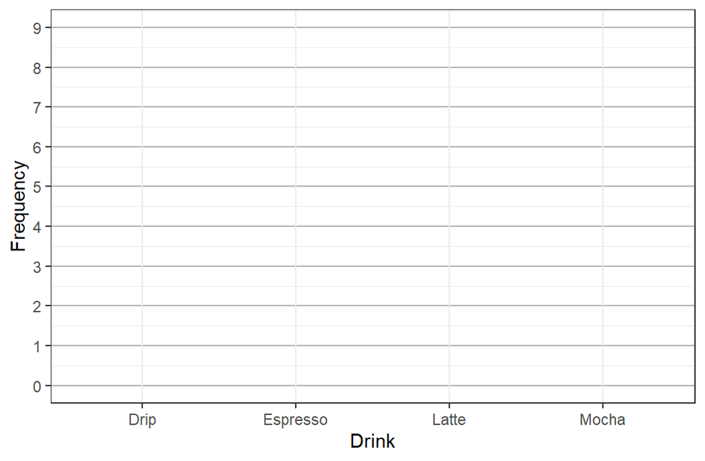

**(d)** A classmate suggests drawing a **histogram** of the drinks instead. Why will that not work? Of the displays we have met — bar graph, pie chart, Pareto chart, histogram, stem-and-leaf plot, dot plot, boxplot — say which are for qualitative data and which require a quantitative variable.

| Display | Qualitative or quantitative? |
| --- | --- |
| Bar graph |  |
| Pie chart |  |
| Pareto chart |  |
| Histogram |  |
| Stem-and-leaf plot |  |
| Dot plot |  |
| Boxplot |  |

**(e)** Would it make sense to add a *cumulative relative frequency* column to the table in part (a)? Explain.

## Problem 5 — Frequency tables and the mean from a table

Twenty-five households were asked how many vehicles they own. The responses are summarized below.

| Vehicles $x$ | Frequency $F(x)$ | Relative frequency $RF(x)$ | Cumulative relative frequency $CRF(x)$ |
| --- | --- | --- | --- |
| 0 | 3 | 0.12 | 0.12 |
| 1 | 9 |  | 0.48 |
| 2 | 8 | 0.32 |  |
| 3 |  |  | 0.96 |
| 4 | 1 |  |  |

**(a)** Fill in the blank entries in the table. Remember that the frequencies must add to $n$, the relative frequencies must add to $1$, and each cumulative relative frequency is the running total of the relative frequencies above it.

**(b)** Show how to compute the mean number of vehicles using the **frequency** from the table above.

**(c)** Now show how to compute the mean again using the **relative frequency** from the table above, and confirm you get the same answer.

**(d)** What proportion of these households own 2 or fewer vehicles?

$\_\_\_\_\_\_\_\_$

**(e)** Use the table to find the median number of vehicles owned.

## Problem 6 — Binned frequency tables and histograms

The following are the times, in seconds, that 16 users took to complete a task on a website.

$$\begin{gathered}
X = \{ 12.4, \ 14.1, \ 15.8, \ 16.2, \ 17.5, \ 18.0, \ 18.3, \ 19.1, \
20.2, \ 20.6, \\
21.7, \ 22.4, \ 23.9, \ 25.1, \ 26.8, \ 28.4 \}
\end{gathered}$$

**(a)** Complete the frequency table using the intervals given. (The bins are always handed to you — here, on the exam, and in the homework. Choosing the number of bins or the bin width yourself is never asked for.)

| Time (seconds) | Frequency $F(x)$ | Relative frequency $RF(x)$ |
| --- | --- | --- |
| $12 < x \leq 16$ |  |  |
| $16 < x \leq 20$ |  |  |
| $20 < x \leq 24$ |  |  |
| $24 < x \leq 28.5$ |  |  |

**(b)** Draw the histogram on the axes below.

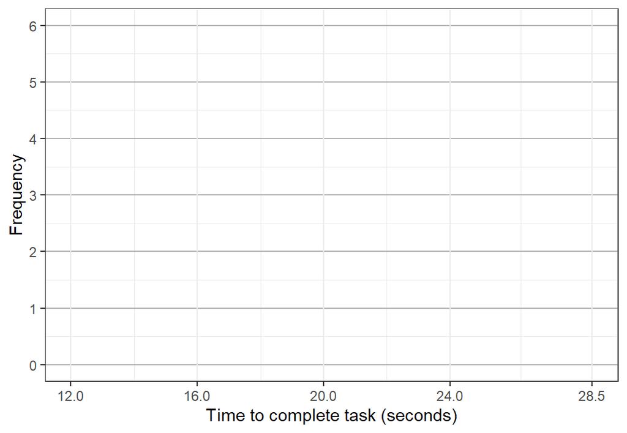

**(c)** Describe the shape of this distribution.

**(d)** A frequency table reports only how many observations fall in each interval.

1. Using **only** the table from part (a), what proportion of users finished the task in 20 seconds or less?
2. Name one quantity you could compute from the raw times listed above but **not** from the table alone, and say why the table cannot give it to you.

## Problem 7 — Dot plots and stem-and-leaf plots

A biologist recorded the number of eggs in each of 15 birds’ nests:

$$\begin{gathered}
X = \{ 21, \ 24, \ 24, \ 27, \ 28, \ 31, \ 33, \ 33, \ 33, \ 35, \\
38, \ 41, \ 42, \ 44, \ 47 \}
\end{gathered}$$

**(a)** Construct a **stem-and-leaf plot**, using the tens digit as the stem.

```
  2 |
  3 |
  4 |
```

**(b)** Construct a **dot plot** on the number line below.

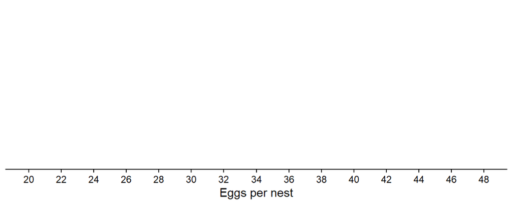

**(c)** What is the mode of this variable?

$\_\_\_\_\_\_\_\_$

**(d)** Is the mode a measure of the center of this distribution? Explain.

## Problem 8 — Center, and what an outlier does to it

Consider the following five observations of a variable $X$, the number of minutes five customers spent in a shop:

$$X = \{ 6, \ 6, \ 9, \ 12, \ 17
\}$$

**(a)** Show how to compute the mean, the median and the mode.

| Statistic | Your answer |
| --- | --- |
| Mean $\bar{x}$ |  |
| Median |  |
| Mode |  |

**(b)** A sixth customer stays for **70 minutes**. Recompute the mean and the median with that observation included. Which of the two moved more, and why?

**(c)** Which of the two is **resistant**? Give a one-sentence definition of that word.

$\_\_\_\_\_\_\_\_$

## Problem 9 — Percentiles and quartiles

The following are the ages of the 10 members of a community board, sorted:

$$X = \{ 29, \ 34, \ 38, \ 41, \ 45, \ 49,
\ 52, \ 56, \ 61, \ 67 \}$$

**(a)** Find the median, $Q2$.

$\_\_\_\_\_\_\_\_$

**(b)** Find $Q1$ and $Q3$ using the **method of halves** we use in this class.

**(c)** An eleventh member, aged $58$, joins the board. Find $Q1$, $Q2$ and $Q3$ for the new set of 11 ages. Remember that when $n$ is odd the median is **left out** of both halves.

**(d)** Using the original 10 ages, what is the $IQR$, and what does it measure?

$\_\_\_\_\_\_\_\_$

**(e)** In the original 10 ages, the board member aged 61 is at roughly what percentile? Answer in a sentence that says what that means.

## Problem 10 — Deviations, variance and standard deviation

A quality inspector took three packets of ground coffee off a filling machine and weighed each one, in grams:

$$X = \{ 48, \ 54, \ 57 \}$$

The sample mean of these three packets is $\bar{x} = \dfrac{159}{3} = 53$ grams.

**(a)** Complete the deviation table below, then add up **each** of the two columns you filled in. You will need the second of those totals again in part (c).

| $x_i$ | $x_i - \bar{x}$ | $(x_i - \bar{x})^2$ |
| --- | --- | --- |
| 48 |  |  |
| 54 |  |  |
| 57 |  |  |

**(b)** A fourth packet comes off the machine weighing **63 grams**. Using the sample mean $\bar{x} = 53$ grams from the three packets above, compute this packet’s deviation from the mean and interpret what that number tells you.

**(c)** Show or explain how to compute the sample variance $s^2$ from the table you filled in above, and then the sample standard deviation $s$.

**(d)** Two students propose simpler measures of spread. Explain what is wrong with each.

1. *“Just average the deviations:”* $\;\dfrac{1}{n}\sum_{i=1}^{n}(x_i - \bar{x})$
2. *“Fine — square them first, then just add them up:”* $\;\sum_{i=1}^{n}(x_i - \bar{x})^{2}$ Consider two samples that are equally spread out, one with $n = 3$ packets and one with $n = 300$.

**(e)** The sample variance divides by $n - 1$, but the sample mean divides by $n$. Why the difference?

**(f)** State the units of $\bar{x}$, of $s^2$ and of $s$.

| Quantity | Units |
| --- | --- |
| $\bar{x}$ |  |
| $s^2$ |  |
| $s$ |  |

**(g)** Show how to compute the range. Which is the better description of the spread of this data, the range or the standard deviation, and why?

## Problem 11 — Five-number summary, boxplots and outliers

A clinic recorded the number of days between a referral and an appointment for 12 patients:

$$\begin{gathered}
X = \{ 3, \ 5, \ 6, \ 8, \ 9, \ 11, \ 12, \ 14, \ 15, \ 17, \\
19, \ 58 \}
\end{gathered}$$

**(a)** Give the five-number summary. Use the method of halves for the quartiles.

| Minimum | Q1 | Median | Q3 | Maximum |
| --- | --- | --- | --- | --- |

**(b)** Show how to compute the $IQR$ and both outlier boundaries.

**(c)** Which observations, if any, does the $1.5 \times IQR$ rule flag as outliers?

$\_\_\_\_\_\_\_\_$

**(d)** Draw the boxplot on the axis below. Be careful about where the right whisker ends.

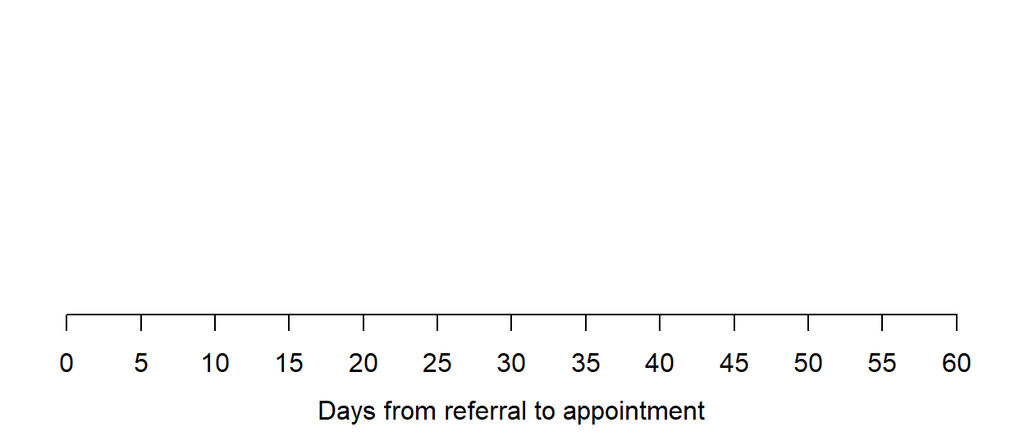

**(e)** Describe the shape of this distribution from the boxplot, and say what that implies about the mean relative to the median.

**(f)** The clinic manager wants to delete the 58-day wait because it is “clearly a mistake.” What would you tell her?

**(g)** A second clinic reports its own referral waits, for 7 patients:

$$W = \{ 1, \ 14, \ 16, \ 18, \ 21, \ 22,
\ 33 \}$$

Find $Q1$, $Q3$ and both boundaries, and say which observations the $1.5 \times IQR$ rule flags. Check **both** boundaries before you answer.

**(h)** Why is it worth drawing a histogram or dot plot alongside a boxplot, rather than relying on the boxplot alone?

## Problem 12 — Cumulative distributions

A librarian recorded the number of books checked out by each of 20 patrons in one hour.

**(a)** Complete the table.

| Books $x$ | Frequency $F(x)$ | Relative frequency $RF(x)$ | Cumulative relative frequency $CRF(x)$ |
| --- | --- | --- | --- |
| 0 | 6 |  |  |
| 1 | 7 |  |  |
| 2 | 3 |  |  |
| 3 | 2 |  |  |
| 4 | 1 |  |  |
| 5 | 1 |  |  |

**(b)** Plot the cumulative distribution on the axes below. Remember it is a **step function**: flat between observed values, jumping at each one.

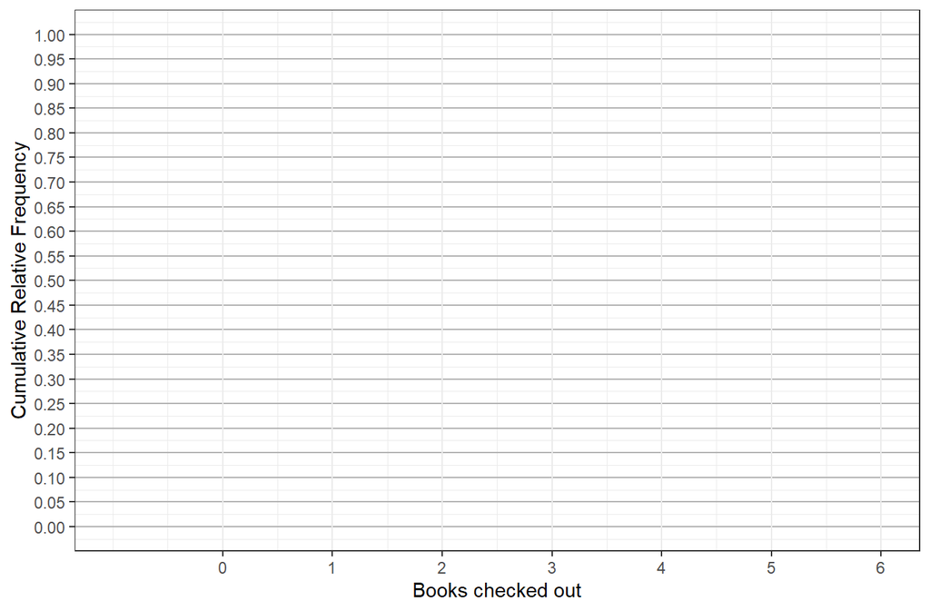

**(c)** Use the plot to find $Q1$, the median, and $Q3$.

**(d)** What proportion of patrons checked out 2 or fewer books?

$\_\_\_\_\_\_\_\_$

**(e)** Describe the shape of this distribution, and say whether the mean will be greater than, less than, or equal to the median.

## Check your work

Worked solutions are posted under **Exam Study Guides → Exam 1 Review → Solutions**. Work each problem through before looking at them.

Every quartile on this exam uses the method of halves. Problem 9 works it both ways: with an odd $n$, where the median is dropped, and with an even $n$, where it is not.